# MarketPulse AI: Business Exit Risk Analysis

Data Cleaning & Exploratory Analysis

Author

Tushar Dhanorkar

Published

June 21, 2026

## The Overview

Every year, hundreds of thousands of Australian businesses open their doors and hundreds of thousands close them. Most of the conversation around the economy focuses on big headline numbers like GDP or unemployment, but there’s a much more immediate signal hiding underneath: **which industries and regions are quietly shedding businesses faster than they’re gaining them.**

That’s the question this project tries to answer, using the Australian Bureau of Statistics’ own record of every business entry and exit in the country between 2021 and 2025. Think of it as a “health check” for the small business economy the kind of analysis a consulting firm might run for a client deciding where to expand, or for a policymaker trying to figure out which regions need support.

By the end of this, the goal is to have:

1. A clear picture of which industries are structurally shrinking (more exits than entries) versus which are genuinely growing
2. A regional lens because national averages hide a lot, and a struggling industry nationally might be thriving in one specific area
3. An AI layer that takes these findings and writes them up the way a consulting analyst would for a client

**Data source:** Australian Bureau of Statistics, *Counts of Australian Businesses, including Entries and Exits*, July 2021 – June 2025.

```r
library(tidyverse)
library(readxl)
```

## Part 1: Industry-level churn (national)

The raw file stacks each financial year as a labelled block of 21 industry rows. We reshape this into a tidy panel: one row per industry per year.

```r
raw <- read_excel(
  "data/8165DC01.xlsx",
  sheet = "Table 1",
  col_names = FALSE
)

col_names <- c(
  "industry",
  "operating_start", "entries_births", "entries_other", "entries_total",
  "exits_cancellations", "exits_other", "exits_total",
  "operating_end", "change", "pct_change", "entry_rate", "exit_rate"
)

year_rows <- which(str_detect(raw[[1]], "^\\d{4}-\\d{2}$"))

clean_year_block <- function(start_row, raw_data) {
  year_label <- raw_data[[1]][start_row]
  block <- raw_data[(start_row + 1):(start_row + 21), 1:13]
  colnames(block) <- col_names
  block %>%
    mutate(year = year_label, .before = 1) %>%
    mutate(across(operating_start:exit_rate, as.numeric))
}

industry_churn <- map_dfr(year_rows, clean_year_block, raw_data = raw) %>%
  filter(industry != "All Industries", industry != "Currently Unknown") %>%
  mutate(
    year_end = as.numeric(str_sub(year, 1, 4)) + 1,
    net_churn_rate = exit_rate - entry_rate
  ) %>%
  relocate(year_end, .after = year)

industry_churn
```

```
# A tibble: 76 × 16
   year    year_end industry        operating_start entries_births entries_other
   <chr>      <dbl> <chr>                     <dbl>          <dbl>         <dbl>
 1 2021-22     2022 Agriculture, F…          173062          10559          4955
 2 2021-22     2022 Mining                     8015            828           356
 3 2021-22     2022 Manufacturing             85793           9359          3420
 4 2021-22     2022 Electricity, G…            7947           1005           312
 5 2021-22     2022 Construction             410646          53819         26532
 6 2021-22     2022 Wholesale Trade           80423           8708          2994
 7 2021-22     2022 Retail Trade             149024          21520          6341
 8 2021-22     2022 Accommodation …          105947          15644          4255
 9 2021-22     2022 Transport, Pos…          196839          38058         16795
10 2021-22     2022 Information Me…           23537           3064          1319
# ℹ 66 more rows
# ℹ 10 more variables: entries_total <dbl>, exits_cancellations <dbl>,
#   exits_other <dbl>, exits_total <dbl>, operating_end <dbl>, change <dbl>,
#   pct_change <dbl>, entry_rate <dbl>, exit_rate <dbl>, net_churn_rate <dbl>
```

What this gives us is one row per industry per financial year, with the raw counts of businesses entering and exiting, plus ABS’s own entry rate and exit rate percentages. From here, the question becomes: **for each industry, is the exit rate outrunning the entry rate?** If it is, that industry is contracting more businesses are closing than new ones are opening to replace them. I’m calling that gap the **net churn rate**.

## Finding #1: Who’s actually shrinking?

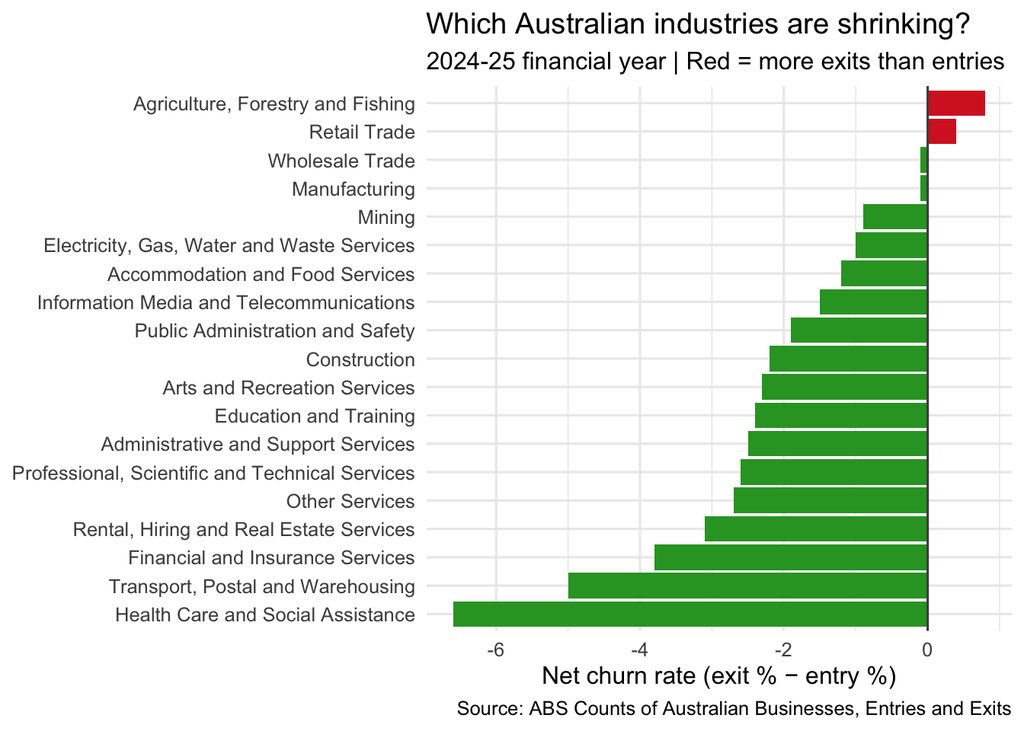

Figure 1: Net churn rate by industry, 2024-25 (positive = shrinking)

```r
industry_churn %>%
  filter(year == "2024-25") %>%
  mutate(industry = fct_reorder(industry, net_churn_rate)) %>%
  ggplot(aes(x = industry, y = net_churn_rate, fill = net_churn_rate > 0)) +
  geom_col() +
  geom_hline(yintercept = 0, color = "grey30") +
  coord_flip() +
  scale_fill_manual(values = c("TRUE" = "#d62728", "FALSE" = "#2ca02c"), guide = "none") +
  labs(
    x = NULL, y = "Net churn rate (exit % − entry %)",
    title = "Which Australian industries are shrinking?",
    subtitle = "2024-25 financial year | Red = more exits than entries",
    caption = "Source: ABS Counts of Australian Businesses, Entries and Exits"
  ) +
  theme_minimal(base_size = 12)
```

The standout is **Agriculture, Forestry and Fishing** at a net churn rate of 0.8 , but notice how small that is. The honest story is that almost every industry *grew* in 2024-25; only agriculture and retail are in negative territory at all, and even they’re only marginally contracting. So this isn’t widespread collapse , it’s a mostly-expanding economy with two specific laggards worth watching. The trend chart below asks whether those two are a one-off or part of something longer.

## Finding #2: Is this a blip or a trend?

A single year doesn’t tell you much on its own - an industry could shrink once and bounce back. So here’s how entry and exit rates moved across all four years for four industries worth watching: the two current laggards (agriculture, retail), plus construction and hospitality as bellwethers that react quickly to economic conditions.

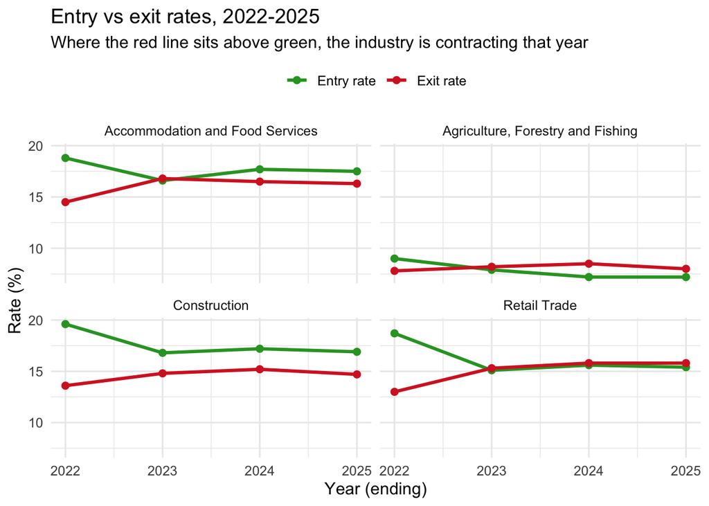

Figure 2: Entry and exit rates over time, selected industries

```r
industry_churn %>%
  filter(industry %in% c(
    "Retail Trade", "Construction", "Accommodation and Food Services",
    "Agriculture, Forestry and Fishing"
  )) %>%
  ggplot(aes(x = year_end)) +
  geom_line(aes(y = entry_rate, color = "Entry rate"), linewidth = 1.1) +
  geom_line(aes(y = exit_rate, color = "Exit rate"), linewidth = 1.1) +
  geom_point(aes(y = entry_rate, color = "Entry rate"), size = 2) +
  geom_point(aes(y = exit_rate, color = "Exit rate"), size = 2) +
  facet_wrap(~industry) +
  scale_color_manual(values = c("Entry rate" = "#2ca02c", "Exit rate" = "#d62728")) +
  labs(
    x = "Year (ending)", y = "Rate (%)", color = NULL,
    title = "Entry vs exit rates, 2022-2025",
    subtitle = "Where the red line sits above green, the industry is contracting that year"
  ) +
  theme_minimal(base_size = 12) +
  theme(legend.position = "top")
```

Wherever the red (exit) line crosses above the green (entry) line, that industry shrank that year. Worth noting which of these four are consistently above the line versus which only dipped once that distinction is exactly what separates a genuine structural problem from a one-off shock.

```r
read_lga_sheet <- function(sheet_name, year) {
  read_excel(
    "data/8165DC10.xlsx",
    sheet = sheet_name,
    skip = 7,
    col_names = c(
      "state", "lga_code", "lga_name", "industry_code", "industry_label",
      "non_employing", "emp_1_4", "emp_5_19", "emp_20_199", "emp_200_plus",
      "total_businesses"
    )
  ) %>%
    mutate(year = year, .before = 1) %>%
    filter(!is.na(state), !str_starts(state, "Total"))
}

lga_panel <- bind_rows(
  read_lga_sheet("Table 1", 2025),
  read_lga_sheet("Table 2", 2024),
  read_lga_sheet("Table 3", 2023)
) %>%
  mutate(total_businesses = as.numeric(total_businesses)) %>%
  filter(!industry_label %in% c("Total", "Currently Unknown"))

lga_yoy <- lga_panel %>%
  select(year, state, lga_code, lga_name, industry_code, industry_label, total_businesses) %>%
  pivot_wider(names_from = year, values_from = total_businesses, names_prefix = "y") %>%
  mutate(
    pct_change_24_25 = (y2025 - y2024) / y2024 * 100,
    pct_change_23_24 = (y2024 - y2023) / y2023 * 100
  )

lga_yoy
```

```
# A tibble: 10,586 × 10
   state        lga_code lga_name industry_code industry_label y2025 y2024 y2023
   <chr>           <dbl> <chr>    <chr>         <chr>          <dbl> <dbl> <dbl>
 1 New South W…    10050 Albury   A             Agriculture, …   263   254   257
 2 New South W…    10050 Albury   B             Mining             3     3     4
 3 New South W…    10050 Albury   C             Manufacturing    206   212   203
 4 New South W…    10050 Albury   D             Electricity, …   145   144   141
 5 New South W…    10050 Albury   E             Construction    1017  1025  1017
 6 New South W…    10050 Albury   F             Wholesale Tra…   134   141   151
 7 New South W…    10050 Albury   G             Retail Trade     282   285   291
 8 New South W…    10050 Albury   H             Accommodation…   258   267   250
 9 New South W…    10050 Albury   I             Transport, Po…   379   354   345
10 New South W…    10050 Albury   J             Information M…    27    26    24
# ℹ 10,576 more rows
# ℹ 2 more variables: pct_change_24_25 <dbl>, pct_change_23_24 <dbl>
```

## Finding #3: National numbers hide regional stories

Everything in Part 1 was a national average - but Australia isn’t one economy, it’s hundreds of local ones. A national average can hide a region that’s in real trouble, or one quietly thriving against the national trend. This is where it gets genuinely useful for a business deciding where to expand, or a council figuring out where support is actually needed.

ABS doesn’t publish entry/exit rates at the regional level - just raw business counts by Local Government Area, for three separate years. So I’m building my own churn proxy here: how much did the business count in each LGA-industry combination change year over year.

### The big picture first: how widespread is this?

Before zooming into specific regions, worth asking - is shrinkage the exception or becoming the norm?

```r
lga_yoy %>%
  filter(y2024 >= 50) %>%
  mutate(direction = if_else(pct_change_24_25 >= 0, "Growing", "Shrinking")) %>%
  count(direction) %>%
  mutate(pct = round(n / sum(n) * 100, 1)) %>%
  knitr::kable(col.names = c("Direction", "Count", "% of all combinations"))
```

| Direction | Count | % of all combinations |
| --- | --- | --- |
| Growing | 2911 | 65 |
| Shrinking | 1570 | 35 |

Roughly two-thirds of LGA-industry combinations grew and a third shrank - so contraction isn’t the dominant story nationally, but it’s far from rare either. That third is exactly where the interesting regional stories live.

### Which states are under the most pressure?

```r
state_summary <- lga_yoy %>%
  filter(y2024 >= 50) %>%
  group_by(state) %>%
  summarise(
    avg_change = mean(pct_change_24_25, na.rm = TRUE),
    n_combos = n(),
    pct_shrinking = mean(pct_change_24_25 < 0, na.rm = TRUE) * 100
  ) %>%
  arrange(avg_change)

state_summary %>%
  knitr::kable(
    col.names = c("State", "Avg % change", "LGA × industry combos", "% combos shrinking"),
    digits = 1,
    caption = "Business count growth by state, 2024 to 2025"
  )
```

Business count growth by state, 2024 to 2025

| State | Avg % change | LGA × industry combos | % combos shrinking |
| --- | --- | --- | --- |
| Tasmania | 0.2 | 201 | 48.8 |
| New South Wales | 1.5 | 1388 | 36.0 |
| Victoria | 1.5 | 1051 | 38.1 |
| South Australia | 1.6 | 498 | 38.2 |
| Australian Capital Territory | 1.6 | 18 | 22.2 |
| Northern Territory | 1.6 | 57 | 35.1 |
| Queensland | 2.2 | 565 | 30.6 |
| Western Australia | 3.1 | 696 | 26.6 |
| Other Territories/Currently Unknown | 7.0 | 7 | 14.3 |

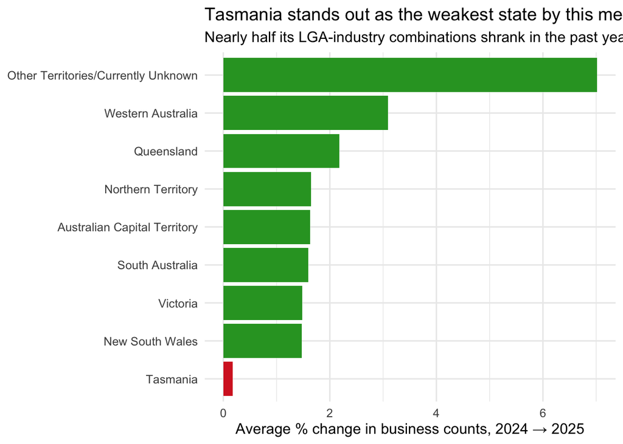

Figure 3: Average business count growth by state

```r
state_summary %>%
  mutate(state = fct_reorder(state, avg_change)) %>%
  ggplot(aes(x = state, y = avg_change, fill = avg_change < 1)) +
  geom_col() +
  coord_flip() +
  scale_fill_manual(values = c("TRUE" = "#d62728", "FALSE" = "#2ca02c"), guide = "none") +
  labs(
    x = NULL, y = "Average % change in business counts, 2024 → 2025",
    title = "Tasmania stands out as the weakest state by this measure",
    subtitle = "Nearly half its LGA-industry combinations shrank in the past year"
  ) +
  theme_minimal(base_size = 12)
```

### The key question: do the same industries struggle everywhere?

This is really the question the whole project is built around. Part 1 showed which industries are contracting *nationally*. Does that national pattern actually hold up when you look at the regional data - or are national averages just smoothing over a much messier reality?

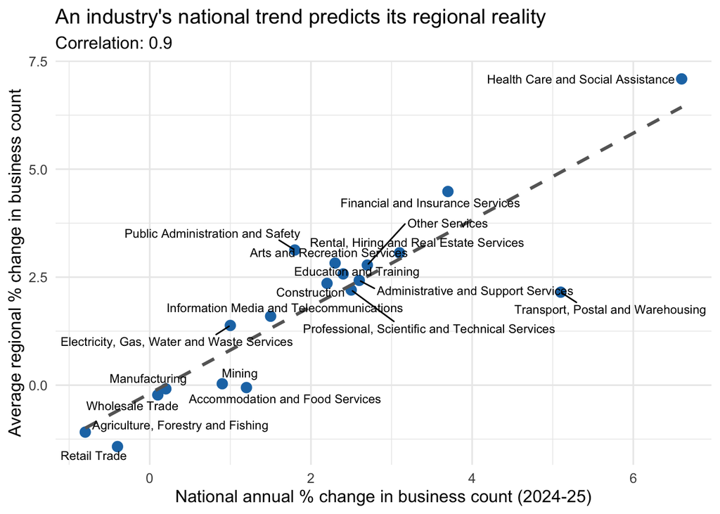

```r
national_industry_change <- industry_churn %>%
  filter(year == "2024-25") %>%
  select(industry, pct_change_national = pct_change)

regional_industry_avg <- lga_yoy %>%
  filter(y2024 >= 50) %>%
  group_by(industry_label) %>%
  summarise(avg_regional_change = mean(pct_change_24_25, na.rm = TRUE), n = n())

cross_check <- national_industry_change %>%
  left_join(regional_industry_avg, by = c("industry" = "industry_label"))

correlation <- cor(cross_check$pct_change_national, cross_check$avg_regional_change, use = "complete.obs")

cross_check %>%
  ggplot(aes(x = pct_change_national, y = avg_regional_change)) +
  geom_point(size = 3, color = "#1f77b4") +
  geom_smooth(method = "lm", se = FALSE, color = "grey40", linetype = "dashed") +
  ggrepel::geom_text_repel(aes(label = industry), size = 3, max.overlaps = 15) +
  labs(
    x = "National annual % change in business count (2024-25)",
    y = "Average regional % change in business count",
    title = "An industry's national trend predicts its regional reality",
    subtitle = paste0("Correlation: ", round(correlation, 2))
  ) +
  theme_minimal(base_size = 12)
```

This is the strongest finding in the analysis: a correlation of **0.9** between how an industry is changing nationally and how its businesses are actually performing on the ground, region by region. Both are independent growth measures , national count change versus the average local change , so this isn’t circular: it’s genuine evidence that the national signal holds up locally. An industry growing nationally tends to grow in most regions, and a declining one declines fairly broadly. For a consulting memo, that’s the kind of result you can lead with confidently: the national picture isn’t masking a messier regional reality.

### Closer look at home turf

```r
lga_yoy %>%
  filter(y2024 >= 50) %>%
  arrange(pct_change_24_25) %>%
  select(state, lga_name, industry_label, y2024, y2025, pct_change_24_25) %>%
  head(10) %>%
  knitr::kable(
    col.names = c("State", "LGA", "Industry", "2024 count", "2025 count", "% change"),
    digits = 1,
    caption = "Sharpest regional declines, 2024 to 2025"
  )
```

Table 1: Sharpest regional declines, 2024 to 2025

| State | LGA | Industry | 2024 count | 2025 count | % change |
| --- | --- | --- | --- | --- | --- |
| Victoria | Queenscliffe | Professional, Scientific and Technical Services | 74 | 58 | -21.6 |
| New South Wales | Federation | Health Care and Social Assistance | 52 | 41 | -21.2 |
| New South Wales | Eurobodalla | Education and Training | 51 | 42 | -17.6 |
| South Australia | Yorke Peninsula | Transport, Postal and Warehousing | 64 | 53 | -17.2 |
| New South Wales | Singleton | Administrative and Support Services | 104 | 87 | -16.3 |
| New South Wales | Blacktown | Agriculture, Forestry and Fishing | 153 | 128 | -16.3 |
| Queensland | Maranoa | Retail Trade | 100 | 84 | -16.0 |
| Tasmania | Huon Valley | Accommodation and Food Services | 69 | 58 | -15.9 |
| New South Wales | Cootamundra-Gundagai Regional | Manufacturing | 51 | 43 | -15.7 |
| Queensland | Weipa | Construction | 51 | 43 | -15.7 |

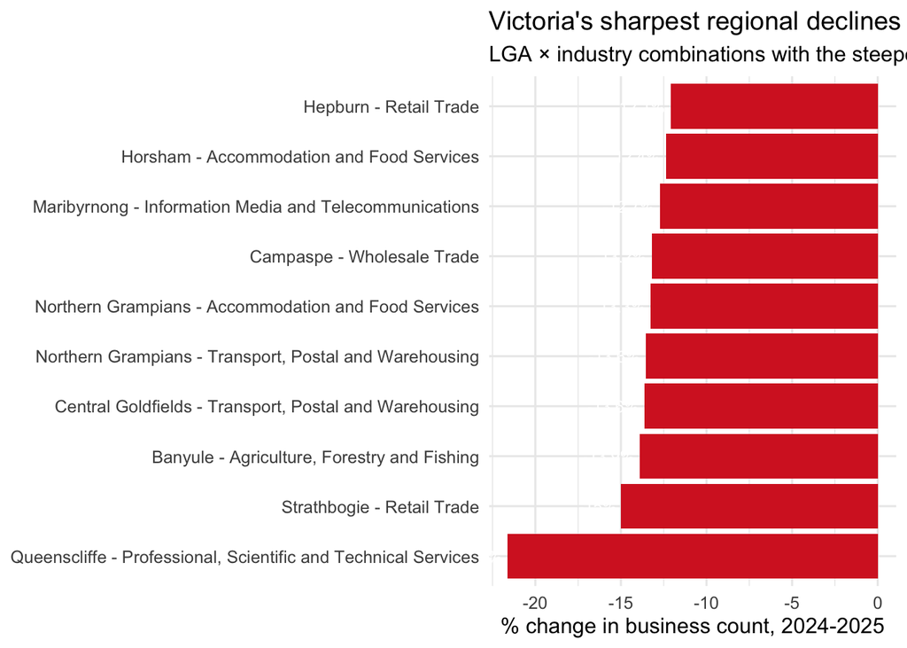

Figure 4: Victorian LGA x industry combinations with sharpest decline, 2024-25

```r
lga_yoy %>%
  filter(state == "Victoria", y2024 >= 50) %>%
  arrange(pct_change_24_25) %>%
  head(10) %>%
  mutate(label = paste(lga_name, industry_label, sep = " - ")) %>%
  mutate(label = fct_reorder(label, pct_change_24_25)) %>%
  ggplot(aes(x = label, y = pct_change_24_25)) +
  geom_col(fill = "#d62728") +
  geom_text(aes(label = paste0(round(pct_change_24_25, 1), "%")), hjust = 1.1, color = "white", size = 3.2) +
  coord_flip() +
  labs(
    x = NULL, y = "% change in business count, 2024-2025",
    title = "Victoria's sharpest regional declines",
    subtitle = "LGA × industry combinations with the steepest drop in business count"
  ) +
  theme_minimal(base_size = 12)
```

```r
dir.create("outputs", showWarnings = FALSE)
write_csv(industry_churn, "outputs/industry_churn_panel.csv")
write_csv(lga_panel, "outputs/lga_industry_panel.csv")
write_csv(lga_yoy, "outputs/lga_industry_yoy_change.csv")
```

The honest takeaway: most Australian industries actually grew in 2024-25 , only agriculture and retail are marginally contracting nationally, so this isn’t a story of widespread decline. What *is* striking is how consistently the national trend holds at the regional level (correlation 0.9): an industry’s national direction reliably predicts how it’s doing locally, region by region. The national picture isn’t hiding a messier regional one.

Tasmania stood out as the state under the most pressure, with the highest share of LGA-industry combinations actually shrinking - a finding a national headline figure would never surface.

That’s a solid analytical foundation, but it’s still just numbers in tables and charts. The next phase is about turning that into something a business or policymaker could actually act on:

- Bring in ABS CPI data to test whether cost pressure is actually driving these exits, or whether something else explains it
- Group industries and regions into proper risk profiles instead of just ranking them individually
- Build an AI layer that takes these findings and writes them up the way a consulting analyst would for a client - the part that turns this from a data project into a tool

## The AI Layer: Auto-Generated Consulting Memo

This is where the project goes from analysis to tool. Instead of a human writing up these findings, I feed the actual numbers , the national churn picture, the correlation, the weakest state , into an LLM (Llama 3.3 70B via Groq) and have it draft a consulting-style memo. The key design choice: the model only gets the real figures my analysis produced, so it narrates the data rather than inventing it.

```r
library(httr2)

# Pull the actual findings into a compact brief for the model
weakest_state <- state_summary %>% slice(1)
top_decline <- lga_yoy %>% filter(y2024 >= 50) %>% arrange(pct_change_24_25) %>% slice(1)

findings_brief <- paste0(
  "ANALYSIS FINDINGS (all figures are real, from ABS 2024-25 data):\n",
  "- Most industries grew nationally; only ",
  paste(industry_churn %>% filter(year == "2024-25", net_churn_rate > 0) %>% pull(industry), collapse = " and "),
  " had more exits than entries.\n",
  "- Top national laggard: ", top_shrinking$industry,
  " (net churn rate ", round(top_shrinking$net_churn_rate, 1), ").\n",
  "- Correlation between national and regional industry trends: ", round(correlation, 2),
  " (national signal holds up locally).\n",
  "- Weakest state: ", weakest_state$state,
  " (avg change ", round(weakest_state$avg_change, 1), "%, ",
  round(weakest_state$pct_shrinking, 0), "% of its industry-region combos shrinking).\n",
  "- Sharpest single regional decline: ", top_decline$industry_label, " in ",
  top_decline$lga_name, " (", round(top_decline$pct_change_24_25, 1), "%)."
)

system_prompt <- "You are a senior analyst at a management consulting firm. Write a concise, professional internal memo (250-300 words) based ONLY on the findings provided. Use this structure: SITUATION, KEY INSIGHTS, RECOMMENDATION. Be precise with the numbers given. Do not invent any statistics not in the brief. Write for a partner who needs the takeaway fast."

resp <- request("https://api.groq.com/openai/v1/chat/completions") %>%
  req_auth_bearer_token(Sys.getenv("GROQ_API_KEY")) %>%
  req_body_json(list(
    model = "llama-3.3-70b-versatile",
    messages = list(
      list(role = "system", content = system_prompt),
      list(role = "user", content = findings_brief)
    ),
    temperature = 0.3
  )) %>%
  req_perform()

memo <- resp %>% resp_body_json() %>% pluck("choices", 1, "message", "content")
cat(memo)
```

**Internal Memo**

**SITUATION**: Our analysis of the latest ABS data (2024-25) reveals a mixed picture of industry growth across Australia. While most industries have experienced national growth, some sectors and regions are struggling.